# 5 - Conversion to and from tidytext_SOLVED

2026-03-10

# Conversion to and from tidytext

So far, we have been working with text in the tidy format, which is one token per row in this structure:

| Document | Word / term | Count |
| --- | --- | --- |
| Document 1 | word 1 | 65 |
| Document 1 | word 2 | 23 |
| Document 2 | word 3 | 18 |

The `tidytext` package has allowed us to work directly with libraries like `dplyr`, `tidyr` or `ggplot2`.

However, there are other text formats to work with, and we need to be able to combine the tidy text with other data structures.

### Document-term matrix

The document-term matrix (DTM) is a common structure for text mining packages to work with, where:

- Each row is a document
- Each column is a term
- Values are the number of appearances of each term in each document

|  | Term 1 | Term 2 | Term 3 |
| --- | --- | --- | --- |
| **Document 1** | 7 | 4 | 12 |
| **Document 2** | 21 | 8 | 5 |
| **Document 3** | 15 | 11 | 1 |

Nevertheless, this example does not reflect what happens in real life. **Normally, most pairings of document and term do not occur, so most elements have a zero value**. We need to convert the matrix into a sparse matrix.

To represent our text collection, we save a sparse matrix with only non-zeros and their positions for two reasons:

- Because we are only interested in non-zero elements (terms actually appearing in documents).
- Because they are more efficient by saving memory and computation.

### Conversion from tidytext to DTM and back

To convert a collection of texts from a DTM to the tidy format we use the function `tidy()`.

To convert from texts in tidy format to DTMs, we use the function `cast()`, which offers three different options:

- cast_sparse() converts into a sparse matrix of the `Matrix` package
- cast_dtm() converts into a dtm of the `tm` package **(most common)**
- cast_dfm() converts into a dfm object from `quanteda` package

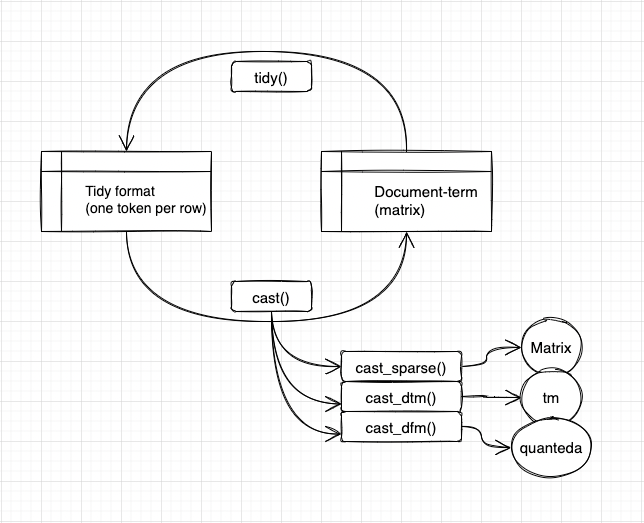

Conversion scheme

Quanteda is a text mining package that we will be exploring further in next sections.

### From DTM to tidy: newspaper articles

Let’s begin by exploring a real DTM of newspaper articles from the Associated Press. It is a bunch of data included in the `topicmodels` package. Just have a look at it.

```r
# install.packages("topicmodels")
```

```r
library(tm)
data("AssociatedPress", package = "topicmodels")
AssociatedPress
```

```
## <<DocumentTermMatrix (documents: 2246, terms: 10473)>>
## Non-/sparse entries: 302031/23220327
## Sparsity           : 99%
## Maximal term length: 18
## Weighting          : term frequency (tf)
```

A sparsity of 99% means that 99% of the elements in a matrix are zero, and only 1% of the elements are non-zero. We will be working with just 1% of the matrix.

If we want to look at them, we can access the terms in the document with the [`Terms()`](https://rdrr.io/pkg/tm/man/Docs.html) function.

```r
terms <- Terms(AssociatedPress)
tail(terms)
```

```
## [1] "zinoviev" "zone"     "zones"    "zoo"      "zubal"    "zurich"
```

To convert this DTM to a text in tidy format we just use the function `tidy()`.

```r
library(dplyr)
library(tidytext)

tidy_ap <- tidy(AssociatedPress)
tidy_ap
```

```
## # A tibble: 302,031 × 3
##    document term       count
##       <int> <chr>      <dbl>
##  1        1 adding         1
##  2        1 adult          2
##  3        1 ago            1
##  4        1 alcohol        1
##  5        1 allegedly      1
##  6        1 allen          1
##  7        1 apparently     2
##  8        1 appeared       1
##  9        1 arrested       1
## 10        1 assault        1
## # ℹ 302,021 more rows
```

Now we have a tidy dataframe in a style that we know well, and we can use all our tidy tools. We can, for example, perform a sentiment analysis for each term of the collection with the bing lexicon.

```r
ap_sentiments <- tidy_ap %>%
  inner_join(get_sentiments("bing"), by = c(term = "word"))

ap_sentiments
```

```
## # A tibble: 30,094 × 4
##    document term    count sentiment
##       <int> <chr>   <dbl> <chr>
##  1        1 assault     1 negative
##  2        1 complex     1 negative
##  3        1 death       1 negative
##  4        1 died        1 negative
##  5        1 good        2 positive
##  6        1 illness     1 negative
##  7        1 killed      2 negative
##  8        1 like        2 positive
##  9        1 liked       1 positive
## 10        1 miracle     1 positive
## # ℹ 30,084 more rows
```

Likewise, we can visualize which words from the AP articles most often contributed to positive or negative sentiment regarding the number of times they appear:

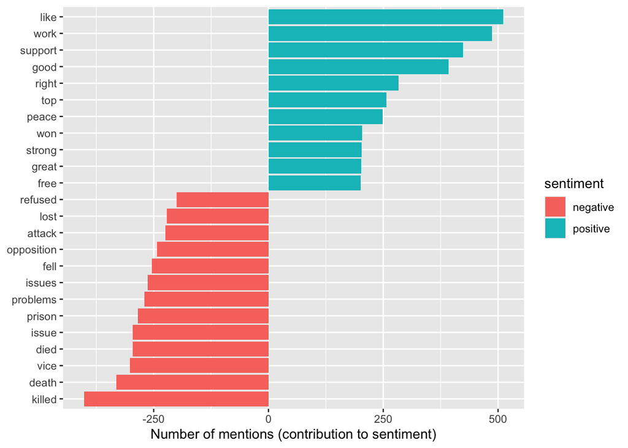

```r
library(ggplot2)
ap_sentiments %>%
  #we weight by the count column: a term and its sentiment associated multiplied by count
  count(sentiment, term, wt = count) %>%
  ungroup() %>%
  #we filter by words appearing more than 200 times in the collection
  filter(n >= 200) %>%
  #creates a new column called n that is equal to the count, but with the sign, to make it negative (to the left in the plot)
  mutate(n = ifelse(sentiment == "negative", -n, n)) %>%
  #reorder for descending order of bars
  mutate(term = reorder(term, n)) %>%
  #plot settings
  ggplot(aes(n, term, fill = sentiment)) +
  geom_col() +
  labs(x = "Number of mentions (contribution to sentiment)", y = NULL)
```

### From DFM to tidy: inaugural speeches

The difference between a Document-term matrix and a Document-feature matrix is that, in DFM, columns can be terms or any other feature from the document, such as named entities or grammatical elements used in the text.

**Keep it simple**: for now, let’s think that DTMs and DFMs work the same, rows are documents and columns are terms.

Let’s explore now a sparse DFM from the quanteda package. It is a corpus of US presidential inauguration speeches. Let’s have a look.

```r
data("data_corpus_inaugural", package = "quanteda")
inaug_dfm <- data_corpus_inaugural %>%
  quanteda::tokens() %>%
  quanteda::dfm(verbose = FALSE)
inaug_dfm
```

```
## Document-feature matrix of: 60 documents, 9,591 features (91.94% sparse) and 4 docvars.
##                  features
## docs              fellow-citizens  of the senate and house representatives :
##   1789-Washington               1  71 116      1  48     2               2 1
##   1793-Washington               0  11  13      0   2     0               0 1
##   1797-Adams                    3 140 163      1 130     0               2 0
##   1801-Jefferson                2 104 130      0  81     0               0 1
##   1805-Jefferson                0 101 143      0  93     0               0 0
##   1809-Madison                  1  69 104      0  43     0               0 0
##                  features
## docs              among vicissitudes
##   1789-Washington     1            1
##   1793-Washington     0            0
##   1797-Adams          4            0
##   1801-Jefferson      1            0
##   1805-Jefferson      7            0
##   1809-Madison        0            0
## [ reached max_ndoc ... 54 more documents, reached max_nfeat ... 9,581 more features ]
```

The `tidy()` function works the same with DFM.

```r
tidy_speeches <- tidy(inaug_dfm)
tidy_speeches
```

```
## # A tibble: 46,402 × 3
##    document        term            count
##    <chr>           <chr>           <dbl>
##  1 1789-Washington fellow-citizens     1
##  2 1797-Adams      fellow-citizens     3
##  3 1801-Jefferson  fellow-citizens     2
##  4 1809-Madison    fellow-citizens     1
##  5 1813-Madison    fellow-citizens     1
##  6 1817-Monroe     fellow-citizens     5
##  7 1821-Monroe     fellow-citizens     1
##  8 1841-Harrison   fellow-citizens    11
##  9 1845-Polk       fellow-citizens     1
## 10 1849-Taylor     fellow-citizens     1
## # ℹ 46,392 more rows
```

Since we have our tidy dataframe, we can easily perform a tf_idf.

```r
speeches_tf_idf <- tidy_speeches |>
  bind_tf_idf(term, document, count) |>
  arrange(desc(tf_idf))

speeches_tf_idf
```

```
## # A tibble: 46,402 × 6
##    document        term        count      tf   idf tf_idf
##    <chr>           <chr>       <dbl>   <dbl> <dbl>  <dbl>
##  1 1793-Washington arrive          1 0.00680  4.09 0.0279
##  2 1793-Washington upbraidings     1 0.00680  4.09 0.0279
##  3 1793-Washington willingly       1 0.00680  3.40 0.0231
##  4 1793-Washington incurring       1 0.00680  3.40 0.0231
##  5 2025-Trump      —              22 0.00657  3.40 0.0224
##  6 1793-Washington previous        1 0.00680  3.00 0.0204
##  7 1793-Washington violated        1 0.00680  3.00 0.0204
##  8 1793-Washington knowingly       1 0.00680  3.00 0.0204
##  9 1793-Washington injunctions     1 0.00680  3.00 0.0204
## 10 1793-Washington witnesses       1 0.00680  3.00 0.0204
## # ℹ 46,392 more rows
```

Let’s choose four representative speeches to analyse the most distinctive words.

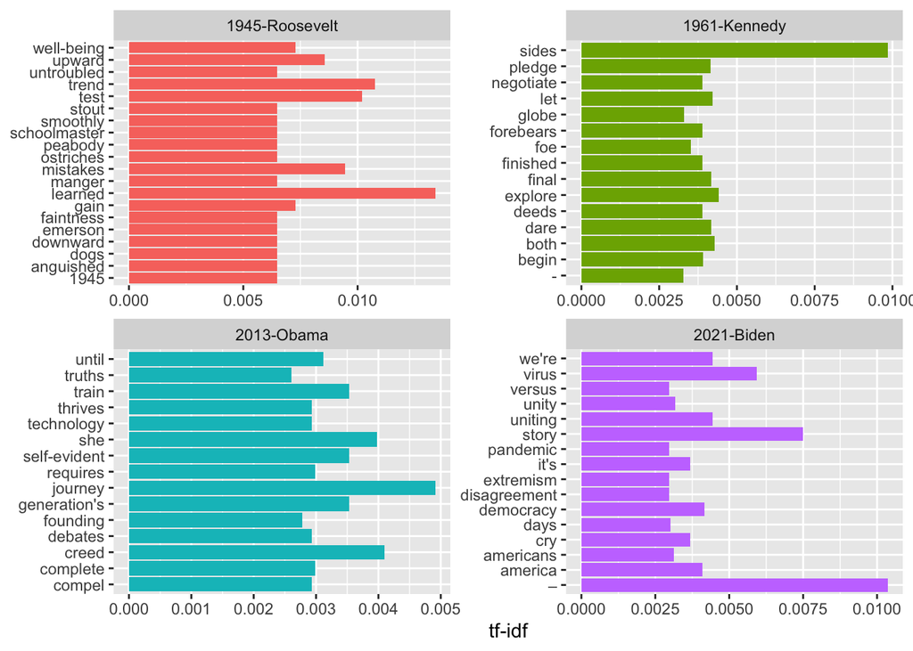

```r
speeches_tf_idf |>
    filter(document %in% c("1945-Roosevelt", "1961-Kennedy","2013-Obama", "2021-Biden")) |>
  group_by(document) |>
  slice_max(tf_idf, n = 15) |>
  ungroup() |>
  mutate(word = reorder(term, tf_idf)) |>
  ggplot(aes(tf_idf, term, fill = document)) +
  geom_col(show.legend = FALSE) +
  labs(x = "tf-idf", y = NULL) +
  facet_wrap(~document, ncol = 2, scales = "free")
```

For each speech there are some ideas that we can highlight and link to reality, to things we know and things we can investigate:

In 1945, Franklin D. Roosevelt is talking about lessons learned so far by his country:

*And so today, in this year of war, 1945, we have learned lessons– at a fearful cost–and we shall profit by them. We have learned that we cannot live alone, at peace; that our own well-being is dependent on the well-being of other nations far away. We have learned that we must live as men, not as ostriches, nor as dogs in the manger.*

In 1961, John F. Kennedy was not talking about separate `sides`, but about mutual understanding with other countries:

*Finally, to those nations who would make themselves our adversary, we offer not a pledge but a request: that both sides begin anew the quest for peace, before the dark powers of destruction unleashed by science engulf all humanity in planned or accidental self-destruction. […] Let both sides explore what problems unite us instead of belaboring those problems which divide us.*

**Exercise (no code)**: Look for the real speeches and find logical narratives for Obama and Biden based on this TF-IDF.

Obama’s Speech:

*Today we continue a never-ending journey to bridge the meaning of those words with the realities of our time. For history tells us that while these truths may be self-evident, they’ve never been self-executing; that while freedom is a gift from God, it must be secured by His people here on Earth. (Applause.) The patriots of 1776 did not fight to replace the tyranny of a king with the privileges of a few or the rule of a mob. They gave to us a republic, a government of, and by, and for the people, entrusting each generation to keep safe our founding creed.*

Biden’s Speech:

*I know speaking of unity can sound to some like a foolish fantasy these days. I know the forces that divide us are deep and they are real. But I also know they are not new. Our history has been a constant struggle between the American ideal that we all are created equal, and the harsh, ugly reality that racism, nativism, fear, demonization have long torn us apart.*

#### Count words by year

This is an easy task with a tricky point.

From the inaugural speeches corpus, we want to extract the year out of each document and then sum up the total number of words per year (=per speech).

```r
library(tidyr)

year_term_counts <- tidy_speeches |>
  #we extract just the digit out of the name of each document
  extract(document, "year", "(\\d+)", convert = TRUE) |>
  #we group by year
  group_by(year) |>
  #we create a new column with the total sum by year
  mutate(year_total = sum(count))

year_term_counts
```

```
## # A tibble: 46,402 × 4
## # Groups:   year [60]
##     year term            count year_total
##    <int> <chr>           <dbl>      <dbl>
##  1  1789 fellow-citizens     1       1537
##  2  1797 fellow-citizens     3       2577
##  3  1801 fellow-citizens     2       1923
##  4  1809 fellow-citizens     1       1261
##  5  1813 fellow-citizens     1       1302
##  6  1817 fellow-citizens     5       3677
##  7  1821 fellow-citizens     1       4886
##  8  1841 fellow-citizens    11       9125
##  9  1845 fellow-citizens     1       5186
## 10  1849 fellow-citizens     1       1178
## # ℹ 46,392 more rows
```

It seems to work OK. Easy so far.

But note that in this tibble **we do not have all words**. We are working originally from a sparse matrix, so for the word count we are losing all zeros: words not appearing in some documents. To do this analysis we need the whole matrix, so we use the function `complete()`.

```r
year_term_counts <- tidy_speeches |>
  extract(document, "year", "(\\d+)", convert = TRUE) |>
  #we complete the matrix with zeros to turn into a dense matrix
  complete(year, term, fill = list(count = 0)) |>
  group_by(year) |>
  mutate(year_total = sum(count))

year_term_counts
```

```
## # A tibble: 575,460 × 4
## # Groups:   year [60]
##     year term  count year_total
##    <int> <chr> <dbl>      <dbl>
##  1  1789 -         1       1537
##  2  1789 –         0       1537
##  3  1789 —         0       1537
##  4  1789 ,        70       1537
##  5  1789 ;         8       1537
##  6  1789 :         1       1537
##  7  1789 !         0       1537
##  8  1789 ?         0       1537
##  9  1789 .        23       1537
## 10  1789 …         0       1537
## # ℹ 575,450 more rows
```

**Note**: `complete()` ensures that all rows have the same columns.

Another important finding here: dfm() base **tokenization settings** are out of our control.

#### Word frequencies over time

Over the `year_term_counts` dataframe, explore how a word has changed its frequency over time in these inaugural speeches can be a good insight too. We can try with “God”, “America”, “constitution” or “freedom”.

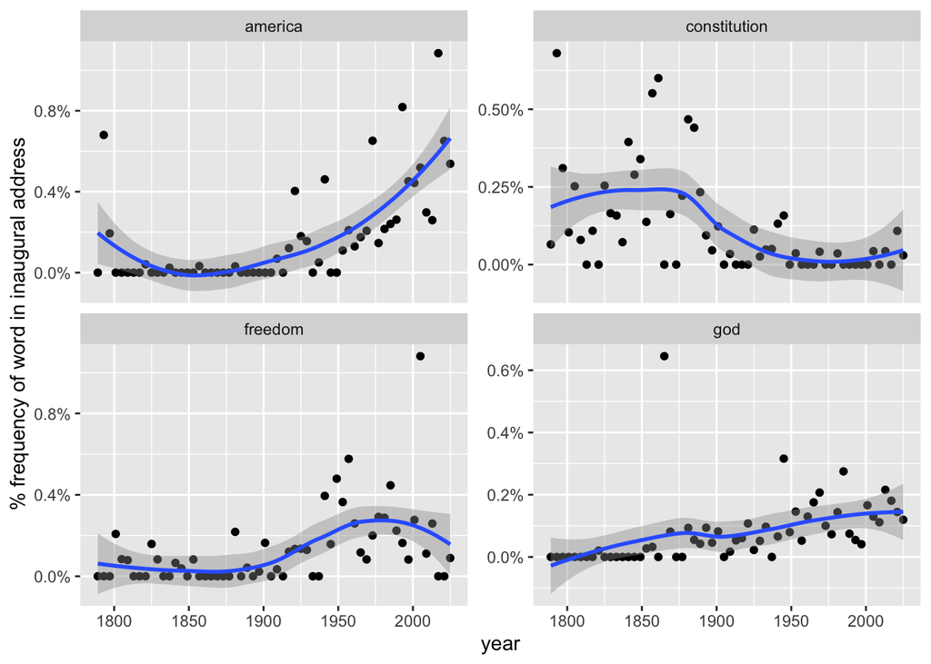

```r
year_term_counts |>
  #we filter by our terms vector
  filter(term %in% c("god", "america", "constitution", "freedom")) |>
  ggplot(aes(year, count / year_total)) +
  geom_point() +
  geom_smooth() +
  facet_wrap(~ term, scales = "free_y") +
  scale_y_continuous(labels = scales::percent_format()) +
  labs(y = "% frequency of word in inaugural address")
```

We can see that `America` is used much more often nowadays. The word `God` is stable, and used more and more across the years, and the word `freedom` has had an increasing use during the 20th century, dropping now. Constitution is less and less used.

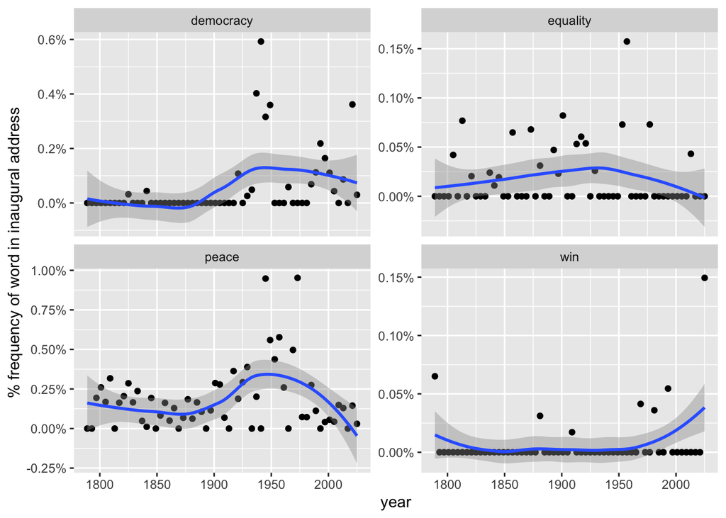

```r
year_term_counts |>
  #we filter by our terms vector
  filter(term %in% c("peace", "win", "equality", "democracy")) |>
  ggplot(aes(year, count / year_total)) +
  geom_point() +
  geom_smooth() +
  facet_wrap(~ term, scales = "free_y") +
  scale_y_continuous(labels = scales::percent_format()) +
  labs(y = "% frequency of word in inaugural address")
```

**Exercise**: try the same analysis with different words. Think of 3-4 interesting concepts that might have changed over time in US inaugural speeches and repeat the plot.

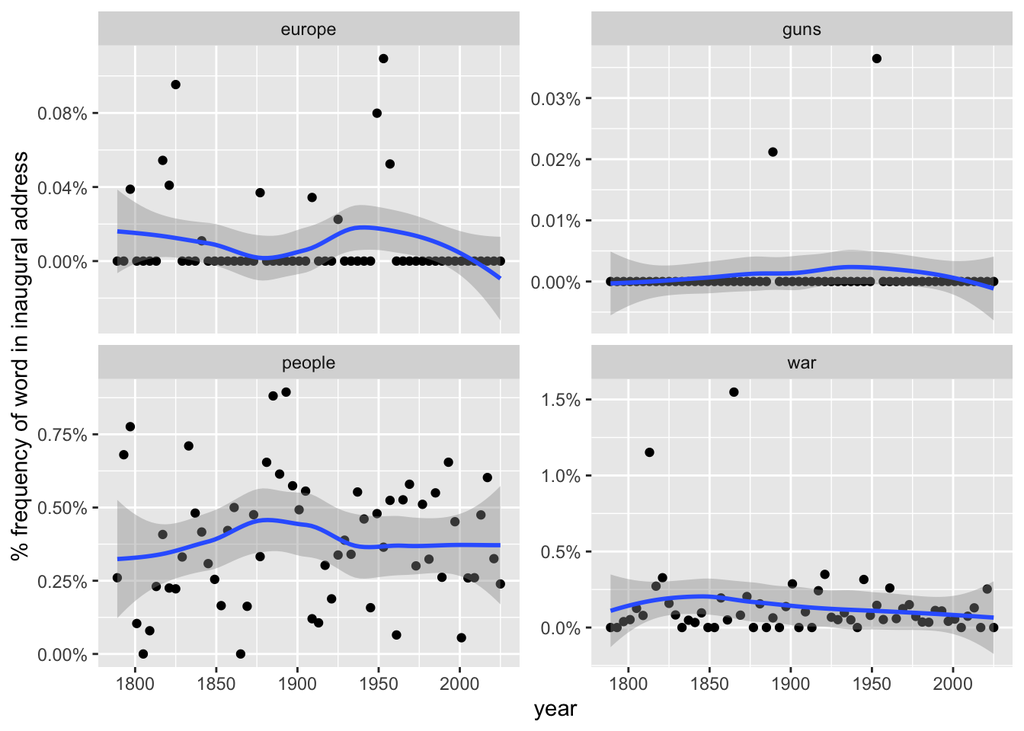

```r
year_term_counts |>
  #we filter by our terms vector
  filter(term %in% c("guns", "people", "europe", "war")) |>
  ggplot(aes(year, count / year_total)) +
  geom_point() +
  geom_smooth() +
  facet_wrap(~ term, scales = "free_y") +
  scale_y_continuous(labels = scales::percent_format()) +
  labs(y = "% frequency of word in inaugural address")
```

## **From tidy into a matrix**

Some text mining tools expect tidy text, and some other expect a matrix. Look again at the diagram to know how to change formats:

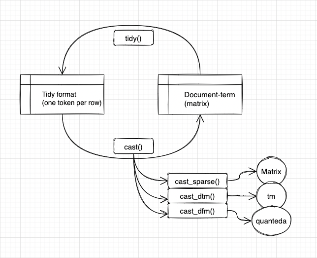

We can take the tidied newspaper articles dataset and cast it back into a document-term matrix using the [`cast_dtm()`](https://rdrr.io/pkg/tidytext/man/document_term_casters.html) function.

```r
dtm_ap <- tidy_ap |>
  #we use the cast function with the three columns needed
  cast_dtm(document, term, count)

dtm_ap
```

```
## <<DocumentTermMatrix (documents: 2246, terms: 10473)>>
## Non-/sparse entries: 302031/23220327
## Sparsity           : 99%
## Maximal term length: 18
## Weighting          : term frequency (tf)
```

Similarly, we could cast the tidy text into a `dfm` object from quanteda’s dfm with [`cast_dfm()`](https://rdrr.io/pkg/tidytext/man/document_term_casters.html).

```r
dfm_ap <- tidy_ap |>
  cast_dfm(document, term, count)

dfm_ap
```

```
## Document-feature matrix of: 2,246 documents, 10,473 features (98.72% sparse) and 0 docvars.
##     features
## docs adding adult ago alcohol allegedly allen apparently appeared arrested
##    1      1     2   1       1         1     1          2        1        1
##    2      0     0   0       0         0     0          0        1        0
##    3      0     0   1       0         0     0          0        1        0
##    4      0     0   3       0         0     0          0        0        0
##    5      0     0   0       0         0     0          0        0        0
##    6      0     0   2       0         0     0          0        0        0
##     features
## docs assault
##    1       1
##    2       0
##    3       0
##    4       0
##    5       0
##    6       0
## [ reached max_ndoc ... 2,240 more documents, reached max_nfeat ... 10,463 more features ]
```

Same thing can be done with Austen books:

```r
library(janeaustenr)

austen_dtm <- austen_books() |>
  #first we create the tidy format, tokenize and count
  unnest_tokens(word, text) |>
  count(book, word) |>
  #second we convert to the matrix: we use the cast function with the three columns needed
  cast_dtm(book, word, n)

austen_dtm
```

```
## <<DocumentTermMatrix (documents: 6, terms: 14520)>>
## Non-/sparse entries: 40379/46741
## Sparsity           : 54%
## Maximal term length: 19
## Weighting          : term frequency (tf)
```

Note that Austen has a sparsity of 54%, which means that only half the matrix are zeros.

- A collection of texts with higher sparsity (e.g. 99%) has a richer and **more diverse vocabulary**, with many unique words or terms that are specific to individual documents or a small number of documents.
- On the other hand, a collection of texts with lower sparsity (e.g. 54%) has a **more similar vocabulary across documents**, with more common words or terms that are shared by many documents.

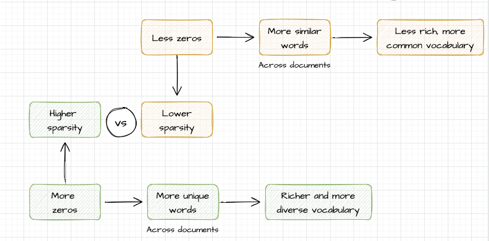

**Exercise: comparing sparsity**

Download any book from Project Gutenberg, create the tidy format filtering stopwords, convert it into a DTM and compare its sparsity. Is its vocabulary richer or poorer than Austen?

```r
library(gutenbergr)
nonfict <- gutenberg_download(c(1228, 205, 4300), mirror = "http://mirror.csclub.uwaterloo.ca/gutenberg/")
```

| **Gutenberg ID** | **Title** | **Author** | **Genre/Topic** |
| --- | --- | --- | --- |
| **1228** | *On the Origin of Species* | Charles Darwin | Science / Biology |
| **205** | *Walden* | Henry David Thoreau | Memoir / Philosophy |
| **4300** | *Ulysses* (Intro/Preface)* | James Joyce / Various | Literary Criticism |

```r
nonfict_dtm <- nonfict |>
  unnest_tokens(word, text) |>
  anti_join(stop_words) |>
  count(gutenberg_id, word) |>
  cast_dtm(gutenberg_id,word,n)
nonfict_dtm
```

```
## <<DocumentTermMatrix (documents: 3, terms: 36116)>>
## Non-/sparse entries: 47731/60617
## Sparsity           : 56%
## Maximal term length: 71
## Weighting          : term frequency (tf)
```

Sparsity in the non-fiction books is 56%, slightly higher but very similar to Austen’s, so we can conclude that they had a similarly rich lexical selection.

## Tidying `tm` corpus objects

In the `tm` package there is an object called Corpus, normally consisting of a collection of texts before tokenization and accompanied by some metadata, such as dates, tags, language or author.

A `tm` `corpus` object is structured like a list, with each item (text) containing both metadata and content.

The `tm` package comes with the `acq` corpus, containing 50 articles from the news service Reuters. Let’s just have a look at it:

```r
data("acq")
acq
```

```
## <<VCorpus>>
## Metadata:  corpus specific: 0, document level (indexed): 0
## Content:  documents: 50
```

```r
# first document
acq[[1]]
```

```
## <<PlainTextDocument>>
## Metadata:  15
## Content:  chars: 1287
```

The first article in the Reuters corpus contains 15 metadata.

Good news is that we can use the [`tidy()`](https://generics.r-lib.org/reference/tidy.html) method to construct a table from a corpus with one row per document, **including this time the metadata** (such as `id` and `datetimestamp`) as columns alongside the `text`. Use the `View()` option to see it in detail.

```r
acq_tidy <- tidy(acq)
acq_tidy
```

```
## # A tibble: 50 × 16
##    author   datetimestamp       description heading id    language origin topics
##    <chr>    <dttm>              <chr>       <chr>   <chr> <chr>    <chr>  <chr>
##  1 <NA>     1987-02-26 15:18:06 ""          COMPUT… 10    en       Reute… YES
##  2 <NA>     1987-02-26 15:19:15 ""          OHIO M… 12    en       Reute… YES
##  3 <NA>     1987-02-26 15:49:56 ""          MCLEAN… 44    en       Reute… YES
##  4 By Cal … 1987-02-26 15:51:17 ""          CHEMLA… 45    en       Reute… YES
##  5 <NA>     1987-02-26 16:08:33 ""          <COFAB… 68    en       Reute… YES
##  6 <NA>     1987-02-26 16:32:37 ""          INVEST… 96    en       Reute… YES
##  7 By Patt… 1987-02-26 16:43:13 ""          AMERIC… 110   en       Reute… YES
##  8 <NA>     1987-02-26 16:59:25 ""          HONG K… 125   en       Reute… YES
##  9 <NA>     1987-02-26 17:01:28 ""          LIEBER… 128   en       Reute… YES
## 10 <NA>     1987-02-26 17:08:27 ""          GULF A… 134   en       Reute… YES
## # ℹ 40 more rows
## # ℹ 8 more variables: lewissplit <chr>, cgisplit <chr>, oldid <chr>,
## #   places <named list>, people <lgl>, orgs <lgl>, exchanges <lgl>, text <chr>
```

Although more complex, this is very similar to the tidy format, and is **prepared to be used with tidy tools**.

We can, for example, find the most common 50 words across the articles:

```r
acq_tokenized <- acq_tidy |>
  #we tokenize
  unnest_tokens(word, text) |>
  #we filter stopwords
  anti_join(stop_words, by = "word")

#we count and order
acq_tokenized |>
  count(word, sort = TRUE)
```

```
## # A tibble: 1,566 × 2
##    word         n
##    <chr>    <int>
##  1 dlrs       100
##  2 pct         70
##  3 mln         65
##  4 company     63
##  5 shares      52
##  6 reuter      50
##  7 stock       46
##  8 offer       34
##  9 share       34
## 10 american    28
## # ℹ 1,556 more rows
```

Or find the most distinctive words for each document.

```r
acq_tokenized |>
  #we keep the id column as the document
  count(id, word) |>
  #we perform tf-idf
  bind_tf_idf(word, id, n) |>
  #we arrange in descending order
  arrange(desc(tf_idf))
```

```
## # A tibble: 2,853 × 6
##    id    word         n     tf   idf tf_idf
##    <chr> <chr>    <int>  <dbl> <dbl>  <dbl>
##  1 186   groupe       2 0.133   3.91  0.522
##  2 128   liebert      3 0.130   3.91  0.510
##  3 474   esselte      5 0.109   3.91  0.425
##  4 371   burdett      6 0.103   3.91  0.405
##  5 442   hazleton     4 0.103   3.91  0.401
##  6 199   circuit      5 0.102   3.91  0.399
##  7 162   suffield     2 0.1     3.91  0.391
##  8 498   west         3 0.1     3.91  0.391
##  9 441   rmj          8 0.121   3.22  0.390
## 10 467   nursery      3 0.0968  3.91  0.379
## # ℹ 2,843 more rows
```

## Real and fake news - `quanteda` corpus

We will be working with a mixed dataset of real and fake news called [news.csv](https://www.kaggle.com/datasets/antonioskokiantonis/newscsv?resource=download) and downloaded from [Kaggle](https://www.kaggle.com/), one of the biggest sources of open datasets.

[Quanteda](http://quanteda.io/) is an R package for managing and analyzing textual data that we have already installed at the beginning of this session. To manage text within quanteda, we need to build a quanteda `corpus` object. We will be building it from our real and fake news file.

### Step 1: Read and prepare the file

Quanteda has a very useful tool called readtext(), which is an easy way to **read text data into R**, from almost any input format. We just need to download the file news.csv, place it in the same folder as this notebook, and read it.

```r
# install.packages("readtext")
```

This function takes a text file or fileset, and returns a type of dataframe that can be used directly with the `corpus()` constructor function, to create a **quanteda** corpus object.

```r
library(readtext)

news <- readtext("news.csv")
news
```

```
## readtext object consisting of 6336 documents and 3 docvars.
## # A data frame: 6,336 × 5
##   doc_id     text           V2                                       V3    V4
##   <chr>      <chr>          <chr>                                    <chr> <chr>
## 1 news.csv.1 "\"NA\"..."    title                                    "tex… label
## 2 news.csv.2 "\"8476\"..."  You Can Smell Hillary’s Fear             "Dan… FAKE
## 3 news.csv.3 "\"10294\"..." Watch The Exact Moment Paul Ryan Commit… "Goo… FAKE
## 4 news.csv.4 "\"3608\"..."  Kerry to go to Paris in gesture of symp… "U.S… REAL
## 5 news.csv.5 "\"10142\"..." Bernie supporters on Twitter erupt in a… "— K… FAKE
## 6 news.csv.6 "\"875\"..."   The Battle of New York: Why This Primar… "It'… REAL
## # ℹ 6,330 more rows
```

The `corpus` object in `quanteda` needs to know where exactly is the text to analyze. This is the most important column, indicated with the argument `text_field`, and all the rests are treated as metadata. In this case, our text column is called **V3**.

We have a problem here, because the first row of the corpus is not really a row, but a header, and we have two columns named `text`, which can lead us to an error.

First thing we need to do is drop the column we don’t really need.

```r
news <- news[-c(2)]
news
```

```
## readtext object consisting of 6336 documents and 2 docvars.
## # A data frame: 6,336 × 5
##   doc_id     V2                                                V3    V4    text
##   <chr>      <chr>                                             <chr> <chr> <chr>
## 1 news.csv.1 title                                             "tex… label "\"\…
## 2 news.csv.2 You Can Smell Hillary’s Fear                      "Dan… FAKE  "\"\…
## 3 news.csv.3 Watch The Exact Moment Paul Ryan Committed Polit… "Goo… FAKE  "\"\…
## 4 news.csv.4 Kerry to go to Paris in gesture of sympathy       "U.S… REAL  "\"\…
## 5 news.csv.5 Bernie supporters on Twitter erupt in anger agai… "— K… FAKE  "\"\…
## 6 news.csv.6 The Battle of New York: Why This Primary Matters  "It'… REAL  "\"\…
## # ℹ 6,330 more rows
```

Second thing is to substitute the header by the first row.

```r
#extract and save the colnames from the first row
#colnames need characters, not lists
colnames(news) <- as.character(unlist(news[1,]))

# remove the first row from the dataset
news <- news[-1,]

news
```

```
## readtext object consisting of 6335 documents and 2 docvars.
## # A data frame: 6,335 × 4
##   news.csv.1 title                                                   text  label
## * <chr>      <chr>                                                   <chr> <chr>
## 1 news.csv.2 You Can Smell Hillary’s Fear                            "\"D… FAKE
## 2 news.csv.3 Watch The Exact Moment Paul Ryan Committed Political S… "\"G… FAKE
## 3 news.csv.4 Kerry to go to Paris in gesture of sympathy             "\"U… REAL
## 4 news.csv.5 Bernie supporters on Twitter erupt in anger against th… "\"—… FAKE
## 5 news.csv.6 The Battle of New York: Why This Primary Matters        "\"I… REAL
## 6 news.csv.7 Tehran, USA                                             "\" … FAKE
## # ℹ 6,329 more rows
```

The problem we’ve got now is that we need to restore the doc_id header. Let’s change the name of the first column.

```r
colnames(news)[colnames(news) == "news.csv.1"] <- "doc_id"
news
```

```
## readtext object consisting of 6335 documents and 2 docvars.
## # A data frame: 6,335 × 4
##   doc_id     title                                                   text  label
## * <chr>      <chr>                                                   <chr> <chr>
## 1 news.csv.2 You Can Smell Hillary’s Fear                            "\"D… FAKE
## 2 news.csv.3 Watch The Exact Moment Paul Ryan Committed Political S… "\"G… FAKE
## 3 news.csv.4 Kerry to go to Paris in gesture of sympathy             "\"U… REAL
## 4 news.csv.5 Bernie supporters on Twitter erupt in anger against th… "\"—… FAKE
## 5 news.csv.6 The Battle of New York: Why This Primary Matters        "\"I… REAL
## 6 news.csv.7 Tehran, USA                                             "\" … FAKE
## # ℹ 6,329 more rows
```

The corpus is OK to work now. See that numbers in the doc_id column are not correlating, but we don’t want to change all docs id. It is more convenient to keep them with their real IDs from the original dataset, just in case.

### Step 2: create the `corpus` object

As we said before, the corpus object in `quanteda` needs to know where exactly is the text to analyze. This is the most important column, indicated specifically, and all the rests are excluded. We need to specifically include the “label” column if we want to keep it.

```r
colnames(news)
```

```
## [1] "doc_id" "title"  "text"   "label"
```

```r
library(quanteda)
# create a corpus object from the readtext data frame including label
news_corpus <- corpus(news$text, docvars = data.frame(label = news$label))
#if label appears in summary, it is fine. View() does not work well with corpus objects.
summary(news_corpus)
```

```
## Corpus consisting of 6335 documents, showing 100 documents:
##
##     Text Types Tokens Sentences label
##    text1   571   1410        87  FAKE
##    text2   297    500        25  FAKE
##    text3   247    478        19  REAL
##    text4   261    469        15  FAKE
##    text5   185    372        21  REAL
##    text6   929   2682       107  FAKE
##    text7   283    619        18  FAKE
##    text8    96    139         5  REAL
##    text9   782   2717       105  REAL
##   text10   351    781        35  REAL
##   text11   337    664        35  REAL
##   text12   240    443        14  REAL
##   text13   156    240        15  FAKE
##   text14    53     59         3  FAKE
##   text15    19     19         1  REAL
##   text16  1169   3706       165  REAL
##   text17   112    154         6  FAKE
##   text18   182    322        18  FAKE
##   text19   513   1287        56  REAL
##   text20   178    323        12  REAL
##   text21   420    889        42  REAL
##   text22   150    223         4  FAKE
##   text23   387    864        38  REAL
##   text24   666   1672        76  REAL
##   text25   448    921        46  FAKE
##   text26   543   1418        51  REAL
##   text27   213    402        19  REAL
##   text28   186    349        14  REAL
##   text29   338    652        34  REAL
##   text30   390    762        29  FAKE
##   text31    28     35         2  REAL
##   text32   302    610        27  FAKE
##   text33   359    865        30  FAKE
##   text34   188    368         9  FAKE
##   text35   584   1531       114  FAKE
##   text36   251    375         8  FAKE
##   text37   210    397        21  FAKE
```

[output cut: 48 more lines]

```
##   text86   351    721        30  REAL
##   text87   187    432        23  REAL
##   text88   360    786        34  REAL
##   text89   362    937        42  REAL
##   text90   471   1161        45  REAL
##   text91    19     19         1  REAL
##   text92   166    345        11  FAKE
##   text93   227    411        17  FAKE
##   text94   301    677        34  REAL
##   text95   292    631        25  REAL
##   text96   253    559        22  FAKE
##   text97  2082   4765        19  FAKE
##   text98   343    826        37  REAL
##   text99   563   1430        64  REAL
##  text100    10     10         1  REAL
```

### Step 3: Apply some analysis

To start with, we might like to know how many of these pieces of news are fake. The corpus object has a function called `table()` to make it easy.

```r
table(news_corpus$label)
```

```
##
## FAKE REAL
## 3164 3171
```

There is a method call `corpus_subset()` that allows to extract a chunk of the dataset according to a condition. For example, all fake news in our corpus.

```r
library(quanteda)
summary(corpus_subset(news_corpus, label == "FAKE"))
```

```
## Corpus consisting of 3164 documents, showing 100 documents:
##
##     Text Types Tokens Sentences label
##    text1   571   1410        87  FAKE
##    text2   297    500        25  FAKE
##    text4   261    469        15  FAKE
##    text6   929   2682       107  FAKE
##    text7   283    619        18  FAKE
##   text13   156    240        15  FAKE
##   text14    53     59         3  FAKE
##   text17   112    154         6  FAKE
##   text18   182    322        18  FAKE
##   text22   150    223         4  FAKE
##   text25   448    921        46  FAKE
##   text30   390    762        29  FAKE
##   text32   302    610        27  FAKE
##   text33   359    865        30  FAKE
##   text34   188    368         9  FAKE
##   text35   584   1531       114  FAKE
##   text36   251    375         8  FAKE
##   text37   210    397        21  FAKE
##   text38   170    316        12  FAKE
##   text39   138    261        14  FAKE
##   text40   353    586        21  FAKE
##   text43    64     76         5  FAKE
##   text44   200    349        19  FAKE
##   text46   325    605        27  FAKE
##   text49   130    217         8  FAKE
##   text50   131    223         9  FAKE
##   text53    29     37         2  FAKE
##   text54    30     36         2  FAKE
##   text55   203    453        17  FAKE
##   text57   409    955        38  FAKE
##   text59    28     33         1  FAKE
##   text61   135    225        11  FAKE
##   text64   271    500        26  FAKE
##   text70   242    418        14  FAKE
##   text72   251    475        14  FAKE
##   text75   145    245        11  FAKE
##   text79    88    162         7  FAKE
```

[output cut: 48 more lines]

```
##  text175   318    636        26  FAKE
##  text176   369    779        34  FAKE
##  text178   822   2094        74  FAKE
##  text180   272    516        18  FAKE
##  text184   228    433        19  FAKE
##  text189   270    506        19  FAKE
##  text192   159    296         7  FAKE
##  text195   197    447        16  FAKE
##  text196   100    138         6  FAKE
##  text198   181    277        10  FAKE
##  text199   640   1460        52  FAKE
##  text202    25     29         2  FAKE
##  text204   775   1682        77  FAKE
##  text205    69     97         3  FAKE
##  text206   304    563        24  FAKE
```

#### Tokenizing

To tokenize a text, `quanteda` provides a useful command called `tokens()`. However, it doesn’t work like the tidy tools: this produces an intermediate object, consisting of **a list of tokens for each document** in the corpus.

```r
tokens(news_corpus)
```

```
## Tokens consisting of 6,335 documents and 1 docvar.
## text1 :
##  [1] "Daniel"     "Greenfield" ","          "a"          "Shillman"
##  [6] "Journalism" "Fellow"     "at"         "the"        "Freedom"
## [11] "Center"     ","
## [ ... and 1,398 more ]
##
## text2 :
##  [1] "Google"      "Pinterest"   "Digg"        "Linkedin"    "Reddit"
##  [6] "Stumbleupon" "Print"       "Delicious"   "Pocket"      "Tumblr"
## [11] "There"       "are"
## [ ... and 488 more ]
##
## text3 :
##  [1] "U.S"       "."         "Secretary" "of"        "State"     "John"
##  [7] "F"         "."         "Kerry"     "said"      "Monday"    "that"
## [ ... and 466 more ]
##
## text4 :
##  [1] "—"           "Kaydee"      "King"        "("           "@KaydeeKing"
##  [6] ")"           "November"    "9"           ","           "2016"
## [11] "The"         "lesson"
## [ ... and 457 more ]
##
## text5 :
##  [1] "It's"          "primary"       "day"           "in"
##  [5] "New"           "York"          "and"           "front-runners"
##  [9] "Hillary"       "Clinton"       "and"           "Donald"
## [ ... and 360 more ]
##
## text6 :
##  [1] "I’m"          "not"          "an"           "immigrant"    ","
##  [6] "but"          "my"           "grandparents" "are"          "."
## [11] "More"         "than"
## [ ... and 2,670 more ]
##
## [ reached max_ndoc ... 6,329 more documents ]
```

`tokens()` is deliberately conservative, meaning that it does not remove anything from the text unless told to do so, but gives us different options to tokenize:

**Exercise**: try setting to `TRUE` the arguments `remove_numbers` and `remove_punct` with text 4 of the `news_corpus`. Then try setting to `FALSE` the argument `remove_separators`.

```r
tokens(news_corpus["text4"], remove_numbers=TRUE, remove_punct=TRUE, remove_separators=TRUE)
```

```
## Tokens consisting of 1 document and 1 docvar.
## text4 :
##  [1] "Kaydee"      "King"        "@KaydeeKing" "November"    "The"
##  [6] "lesson"      "from"        "tonight's"   "Dem"         "losses"
## [11] "Time"        "for"
## [ ... and 365 more ]
```

If we set remove_separators as false, we include spaces as a token.

By default we are tokenizing at the word level, but the `what` argument also allows to tokenize characters or sentences.

```r
tokens(news_corpus["text4"], what = "character")
```

```
## Tokens consisting of 1 document and 1 docvar.
## text4 :
##  [1] "—" "K" "a" "y" "d" "e" "e" "K" "i" "n" "g" "("
## [ ... and 2,232 more ]
```

```r
tokens(news_corpus["text4"], what = "sentence")
```

```
## Tokens consisting of 1 document and 1 docvar.
## text4 :
##  [1] "— Kaydee King (@KaydeeKing) November 9, 2016 The lesson from tonight's Dem losses: Time for Democrats to start listening to the voters."
##  [2] "Stop running the same establishment candidates.  — People For Bernie (@People4Bernie) November 9, 2016 If Dems didn't want a tight race they shouldn't have worked against Bernie.  — Walker Bragman (@WalkerBragman) November 9, 2016  New York Times columnist Paul Krugman, who was one of Hilla…
##  [3] "The account @BerniesTeachers threw Krugman’s analysis back in his face."
##  [4] "Your candidate was the issue."
##  [5] "Take responsibility. https://t.co/KHyOuUSrFS  — Teachers for Bernie (@BerniesTeachers) November 9, 2016  Ana Navarro, a Republican who recently endorsed Hillary Clinton, summed up the preposterous nature of the 2016 presidential election in this tweet: GOP nominated the only damn candidate …
##  [6] "Democrats nominated the only damn candidate who could lose to Trump  — Ana Navarro (@ananavarro) November 9, 2016  Popular left-wing Facebook page The Other 98%, which was pro-Sanders during the primary, responded to Trump’s surge by simply posting a meme of Sanders’ face with the text “All…
##  [7] "Thanks for nothing, DNC!”"
##  [8] "The meme has been shared almost 15,000 times in less than an hour:  Posted by The Other 98% on Tuesday, November 8, 2016  While Bernie Sanders endorsed Hillary Clinton just before the Democratic National Convention in July, many of his supporters remained adamant in their refusal to support…
##  [9] "Rather than attribute a potential Trump presidency to the GOP nominee’s perceived popularity among voters, the closeness of this election could be credited to Hillary Clinton’s unfavorable ratings."
## [10] "According to RealClearPolitics, anywhere between 51 and 57 percent of voters had a negative opinion of the Democratic nominee."
## [11] "As of 11 PM Eastern, Florida, Michigan, Pennsylvania, and Wisconsin remain too close to call."
## [12] "Clinton has 197 electoral votes to Trump’s 187."
## [ ... and 3 more ]
```

This doesn’t work great because “. -” doesn’t register as the end of a sentence.

#### Keyword in context

Another function called `kwic()` allows watching a specific keyword in context.

First you need to apply the function `tokens()`to it. Then, it takes two basic arguments, the corpus and the term.

And it gives an output of four columns:

- The text it comes from and the word index for the search term (not line).
- 5 nearest context words on the left
- The search term
- 5 nearest context words on the right

```r
kwic_result <- kwic(tokens(news_corpus), "terror", window = 5)
kwic_result
```

```
## Keyword-in-context with 559 matches.
##      [text6, 1644]                                    , of Islam as a | terror
##      [text19, 741]                        ties with and stops funding | terror
##      [text21, 411]                   of Christians committing acts of | terror
##      [text23, 281]                       Islanders were killed in the | terror
##      [text23, 407]                  rebuild lower Manhattan after the | terror
##       [text56, 20]                               the site of a grisly | terror
##      [text79, 118]                                  ( in Syria ) from | terror
##     [text85, 2228]                    and displaced when the Islamist | terror
##     [text85, 3687]                              attack, for which the | terror
##     [text85, 4048]                            and mass murders by the | terror
##     [text85, 4254]                              "" ISIL's campaign of | terror
##       [text95, 24]                   in connection with the deadliest | terror
##      [text112, 55]                            were other members of a | terror
##     [text112, 125]                             a suspect in the Paris | terror
##    [text112, 1176]                           or help them dismantle a | terror
##     [text121, 358]                             defiant in the face of | terror
##    [text138, 4436]                                 so called “ war on | terror
##    [text169, 2170]                                         and 7/ 7 “ | terror
##     [text177, 372]                             head and see the sheer | terror
##     [text177, 575]                              . He wanted to invoke | terror
##     [text204, 523]                         savoring a little reign of | terror
##    [text218, 1278]                                on Israel, Iraq and | Terror
##     [text219, 141]                  the verge of committing important | terror
##     [text219, 203]                    trouble by raising the national | terror
##     [text219, 316]                            smoke billowing up. Two | terror
##     [text219, 526]                         said. Authorities said the | terror
##     [text235, 193]                                   for the “ War on | Terror
##     [text270, 668]                           “ an act of journalistic | terror
##     [text282, 523]               are making themselves accomplices to | terror
##     [text285, 333]                           the militants ’ reign of | terror
##     [text300, 559]                                      " lone wolf"" | terror
##    [text368, 1192]                    NDAA America’s so-called war on | terror
##      [text414, 10]                   are reviewing databases of known | terror
##      [text414, 41]                                 . in response. The | terror
##     [text414, 194]              told investigators had been reviewing | terror
##      [text419, 39]                        heading towards a regime of | terror
##     [text435, 117]                       was actually directed by the | terror
##     [text435, 254]                                 this was an act of | terror
##     [text435, 558]                      co-worker"" alleging possible | terror
```

[output cut: 1065 more lines]

```
##  | and propaganda operation dedicated to
##  | then consider Kristalnacht. And
##  | attacks and the San Bernardino
##  | was over. However,
##  | group late Sunday shows nine
##  | November 04, 2016 The
##  | . If we betray them
##  | organization. The gunmen,
##  | group's"" brothers.
##  | group in Iraq and Syria
##  | group gave the gunmen specific
##  | attacks on their own at
##  | bombings in socialist Cuba;
##  | , replete with rampant “
##  | to keep the money flowing
```

```r
kwic_result <- kwic(tokens(news_corpus), "terror", window = 5, valuetype="regex")
kwic_result
```

```
## Keyword-in-context with 3,017 matches.
##        [text3, 34]            attended Sunday’s unity march against |
##      [text6, 1644]                                  , of Islam as a |
##      [text6, 2033]                          United States. This was |
##       [text9, 723]                            , I would have fought |
##      [text19, 741]                      ties with and stops funding |
##      [text21, 359]                          clearly not going to be |
##      [text21, 411]                 of Christians committing acts of |
##      [text23, 281]                     Islanders were killed in the |
##      [text23, 407]                rebuild lower Manhattan after the |
##      [text30, 648]                      confirm 26 killed in action |
##       [text56, 20]                             the site of a grisly |
##      [text60, 247]                              a rallying cry. The |
##      [text67, 405]                confronting the ongoing threat of |
##      [text69, 232] security subcommittee on counterintelligence and |
##     [text69, 1229]                        , was on the government’s |
##     [text69, 1547]                       gun purchases by people on |
##      [text79, 118]                                ( in Syria ) from |
##     [text85, 2228]                  and displaced when the Islamist |
##     [text85, 3687]                            attack, for which the |
##     [text85, 3735]                    online from supporters of the |
##     [text85, 4048]                          and mass murders by the |
##     [text85, 4254]                            "" ISIL's campaign of |
##     [text85, 4642]                  center advocating against hate, |
##       [text95, 24]                 in connection with the deadliest |
##       [text95, 92]                                  men, one with a |
##      [text95, 173]                people dead in France's deadliest |
##      [text95, 183]                        . Thousands of police and |
##      [text95, 301]                   We are facing an unprecedented |
##      [text95, 429]                Kouachi was convicted of abetting |
##      [text96, 298]                             them and call them a |
##      [text97, 427]               pinky-swear promise not to support |
##     [text97, 1071]                     3-day waiting period for all |
##     [text97, 1945]                      fight ISIS with new federal |
##     [text97, 3174]                                was not an act of |
##      [text112, 55]                          were other members of a |
##     [text112, 125]                           a suspect in the Paris |
##     [text112, 151]                         stakes are high, Belgian |
##     [text112, 331]                             but no known ties to |
##     [text112, 359]                             were ) not linked to |
```

[output cut: 2949 more lines]

```
##  , it was to play
##  as a “ scourge that
##  ” and the Islamic State
##  . ” This inspired Kumar
##  , war, a divided
##  . ” Paul thinks that
##  attack, a natural disaster
##  , which it has relentlessly
##  operation targeting an al Qaeda
##  operations including the one that
##  operations in the same region
##  operations."" To
##  operation that killed the hostages
##  policies"" in a
## [ reached max_nrow ... 2,017 more matches]
```

```r
kwic_result <- kwic(tokens(news_corpus),"community*", window=8)
kwic_result
```

```
## Keyword-in-context with 1,169 matches.
##      [text6, 2263]
##      [text6, 2268]
##      [text6, 2307]
##       [text7, 129]
##       [text21, 18]
##      [text32, 239]
##      [text52, 817]
##      [text66, 306]
##      [text66, 759]
##      [text66, 886]
##      [text71, 478]
##      [text83, 662]
##     [text85, 4549]
##     [text85, 4554]
##       [text93, 83]
##      [text93, 101]
##      [text93, 194]
##      [text93, 306]
##     [text97, 2759]
##     [text97, 3591]
##     [text105, 581]
##     [text105, 616]
##     [text106, 471]
##     [text117, 561]
##     [text121, 745]
##     [text123, 271]
##     [text123, 305]
##     [text123, 825]
##     [text137, 738]
##     [text137, 987]
##     [text146, 653]
##    [text146, 1996]
##    [text146, 2269]
##     [text157, 427]
##     [text176, 246]
##     [text176, 486]
##     [text176, 629]
##     [text177, 505]
##     [text177, 580]
```

[output cut: 3950 more lines]

```
##  Church is challenging the town of Gilbert's sign
##  organizer Barack Obama does.
##  and all those who believed in his shitfaced
##  behind supporting various elements of the counter-ISIL campaign
##  will be debating: whether 25 is too
##  about a new age cut off, if
##  simply do not want [ Clinton ] to
##  near the military academy, surrounded by retired
##  were keeping a close watch on their children
##  Guidelines, ” declared the account “ cannot
##  by labeling Mexican immigrants as rapists and criminals
##  as well, ” says Tod Burke,
##  . This is not a form of healthy
##  . Once the deal is implemented, Iran
## [ reached max_nrow ... 169 more matches]
```

We can see community is also including “Community”, or “community’s”.

```r
kwic_result <- kwic(tokens(corpus_subset(news_corpus, label == "FAKE")), "friendship", window=8)
kwic_result
```

```
## Keyword-in-context with 26 matches.
##    [text355, 350]                      . And yet, apart from the beautiful |
##    [text355, 410]                  to the Clinton campaign. Apart from the |
##    [text576, 166]            play the role considering his long history of |
##    [text694, 446]                    But Thomas chose to dwell more on his |
##   [text1059, 385]                partisans and a graduate of the Peoples ’ |
##  [text1360, 8663]                         of the P.I.C.A. was one of great |
##   [text1968, 262]                nothing. Once we have determined that the |
##   [text1968, 856]                 taking care to avoid the reasons why the |
##  [text1968, 1418]                          time; but I would not call this |
##  [text2226, 1059]                    nor is he there because he values his |
##   [text2704, 809]                    the role of Attorney General. And the |
##   [text2935, 646]    status as a billionaire belies both their decades-old |
##   [text3300, 189]   robbed since November, according to the Franco-Chinese |
##   [text3326, 146]              Putin presented state awards - the Order of |
##  [text3458, 1998]           humanity’s development and future. While his ‘ |
##  [text3622, 1478]                         can not have a good marriage, or |
##   [text3822, 228]                  decision to go ahead with its Druzhba ( |
##   [text4018, 938]              ago. The station continued to chronicle the |
##  [text4148, 1700] has declared that Malaysia is committed to strengthening |
##  [text4632, 2364]                   for your life, you don’t question that |
##   [text5073, 539]                       level ). Trump – brags about close |
##  [text5101, 4358]          unoccupied land peacefully, and for seeking the |
##  [text5204, 1018]             confused and incoherent. Let’s hope that his |
##  [text5885, 2049]                   was also paid exceedingly well for it. |
##  [text6035, 1660]  there is Seyyed Hossein Nar’s long-time association and |
##    [text6147, 95]                 the guise of the director of the Dresden |
##
##  friendship | with Gillard, what did Australia get from
##  friendship | between Hillary Clinton and Julia Gillard, what
##  friendship | with the Clintons. In addition, the
##  friendship | with “ Nino ” than ponder the future
##  Friendship | University in Russia as well as a trained
##  friendship | for the Arab. Not only did they
##  friendship | is worth repairing or sustaining, the next
##  friendship | became strained in the first place. Things
##  friendship | . I would call it an uneasy equilibrium
##  friendship | with Syrian President Bashar al Assad. That
##  friendship | between Kadzik and Podesta — as well as
##  friendship | and striking similarities — particularly as darlings of
##  Friendship | Association. “ It is because of prejudices
##  Friendship | and the Medal of Pushkin. The President's
##  Friendship | ’ faction promoted cosmic unity and ethical development
##  friendship | without it. Ask yourself, how many
##  Friendship | ) 2016 military exercises with Pakistan immediately after
##  friendship | and reported the news of Erling’s death.
##  friendship | with China and pushing ties to “ new
##  friendship | . More power to Israel in this fight
##  friendship | with Epstein Before Epstein’s legal problems, Trump
##  friendship | of neighboring peoples, but neither they nor
##  friendship | with Vladimir Putin portends realism, and the
##  Friendship | with the Clintons doesn’t come cheap. As
##  friendship | with Henry Kissinger; the fact that prominent
##  Friendship | House. 3. Family On July 28
```

### Step 4: From corpus to DFM

For multiple purpose, we may need to convert a quanteda corpus to a Document-Feature Matrix, which we have seen is not different from a Document-Term Matrix at this stage.

Let’s create a subset only with fake news to work with it in a DFM.

```r
fake_corpus <- corpus_subset(news_corpus, label == "FAKE")
head(fake_corpus)
```

```
## Corpus consisting of 6 documents and 1 docvar.
## text1 :
## "Daniel Greenfield, a Shillman Journalism Fellow at the Freed..."
##
## text2 :
## "Google Pinterest Digg Linkedin Reddit Stumbleupon Print Deli..."
##
## text4 :
## "— Kaydee King (@KaydeeKing) November 9, 2016 The lesson from..."
##
## text6 :
## "   I’m not an immigrant, but my grandparents are. More than ..."
##
## text7 :
## "Share This Baylee Luciani (left), Screenshot of what Baylee ..."
##
## text13 :
## "Click Here To Learn More About Alexandra's Personalized Esse..."
```

And finally, we may need to apply some stopwords filtering and stemming to the terms before using the `quanteda` `dfm()` function to convert it.

```r
#first, we tokenize with the tokens() function from quanteda
tokens_fake <- tokens(fake_corpus, remove_punct = TRUE)
#second, we filter stopwords using tokens_remove()
tokens_fake_filtered <- tokens_remove(tokens_fake, stopwords("english"))
#third, we apply stemming
tokens_fake_stemmed <- tokens_wordstem(tokens_fake_filtered)
#and finally, we create our dfm using dfm()
fakenews_dfm <- dfm(tokens_fake_stemmed)
fakenews_dfm
```

```
## Document-feature matrix of: 3,164 documents, 49,807 features (99.53% sparse) and 1 docvar.
##         features
## docs     daniel greenfield shillman journal fellow freedom center new york
##   text1       1          1        1       1      1       1      1   3    2
##   text2       0          0        0       0      0       0      0   1    0
##   text4       0          0        0       0      0       0      0   1    1
##   text6       0          0        0       0      4       2      0   5    1
##   text7       0          0        0       0      0       0      0   0    0
##   text13      0          0        0       0      0       0      0   0    0
##         features
## docs     writer
##   text1       1
##   text2       0
##   text4       0
##   text6       0
##   text7       0
##   text13      0
## [ reached max_ndoc ... 3,158 more documents, reached max_nfeat ... 49,797 more features ]
```

#### Stemming

The difference between lemmatization and stemming can be explained briefly, even though the goal of both techniques is to **standardize words** so that different forms of the same word can be treated as the same token.

| Lemmatization | Stemming |
| --- | --- |
| Involves reducing words to their canonical form or lemma | Involves stripping the affixes from a word to obtain its root or stem |
| A lemma is always an existing word that can be found in a dictionary | The resulting stem may not be a real word, but it represents the base form of the word |
| Is slower and more accurate in its reduction of words | Is typically faster and more aggressive in its reduction of words |
| Example: journalism - journalism | Example: journalism - journal |
| Sometimes it doesn’t work with proper nouns or non-dictionary words, that can be lemmatized as <UNKNOWN> | Always works. Proper nouns or non-dictionary words normally stay the same if they have no prefixes. |
| Example: swiftie - <UNKNOWN> | Example: swiftie - swift |

Once we’ve got our perfectly built DFM, we can use the function `topfeatures()` to extract quickly the most often used words in the corpus:

```r
#We extract the 20 top words
topfeatures(fakenews_dfm, 20)
```

```
##  clinton    trump    state    peopl      one       us      can      new
##     6129     5899     5412     5379     5168     4960     4369     4239
##  hillari     like     said     time    elect     just american     year
##     4205     4119     3999     3994     3603     3569     3541     3514
##     also      use      now       go
##     3192     3146     3121     3049
```

For a `DFM` object, plotting a wordcloud is done through the function `textplot_wordcloud()`, that includes some arguments to make it pretty. We will need the packages `quanteda.textplots` and `RColorBrewer`.

```r
# install.packages("RColorBrewer")
```

```r
# install.packages("quanteda.textplots")
```

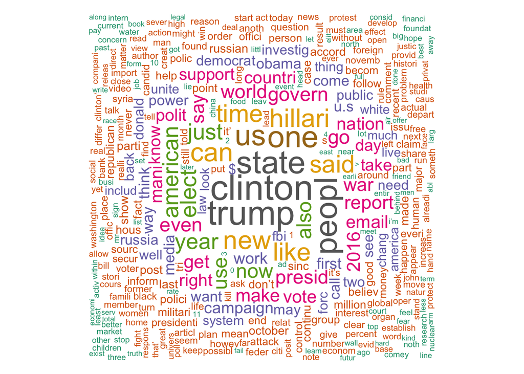

```r
library(quanteda.textplots)
library(RColorBrewer)
#we set a random seed for the cloud to be ordered always the same
set.seed(100)

textplot_wordcloud(fakenews_dfm, min_count = 6, random_order = FALSE,
                   rotation = .25,
                   colors = RColorBrewer::brewer.pal(8,"Dark2"))
```

**Exercise**: repeat the process all over again to create this wordcloud only with real news from the dataset.

- Create a corpus subset only with real news (`real_corpus`)

```r
real_corpus <- corpus_subset(news_corpus, label == "REAL")
head(real_corpus)
```

```
## Corpus consisting of 6 documents and 1 docvar.
## text3 :
## "U.S. Secretary of State John F. Kerry said Monday that he wi..."
##
## text5 :
## "It's primary day in New York and front-runners Hillary Clint..."
##
## text8 :
## "A Czech stockbroker who saved more than 650 Jewish children ..."
##
## text9 :
## "Hillary Clinton and Donald Trump made some inaccurate claims..."
##
## text10 :
## "Iranian negotiators reportedly have made a last-ditch push f..."
##
## text11 :
## "CEDAR RAPIDS, Iowa — “I had one of the most wonderful rallie..."
```

- Convert the corpus to a DFM removing first punctuation and stopwords. Use stemming.

```r
#first, we tokenize with the tokens() function from quanteda
tokens_real <- tokens(real_corpus, remove_punct = TRUE)
#second, we filter stopwords using tokens_remove()
tokens_real_filtered <- tokens_remove(tokens_real, stopwords("english"))
#third, we apply stemming
tokens_real_stemmed <- tokens_wordstem(tokens_real_filtered)
#and finally, we create our dfm using dfm()
realnews_dfm <- dfm(tokens_real_stemmed)
realnews_dfm
```

```
## Document-feature matrix of: 3,171 documents, 40,180 features (99.26% sparse) and 1 docvar.
##         features
## docs     u.s secretari state john f kerri said monday stop pari
##   text3    2         2     5    1 1     7    6      2    1    5
##   text5    0         0     5    1 0     0    0      0    0    0
##   text8    0         0     0    0 0     0    0      0    0    0
##   text9   10         4     6    0 0     0   26      0    1    0
##   text10   8         1     4    1 0     2    5      0    0    0
##   text11   0         0     1    0 0     0    6      1    0    0
## [ reached max_ndoc ... 3,165 more documents, reached max_nfeat ... 40,170 more features ]
```

- Create the wordcloud

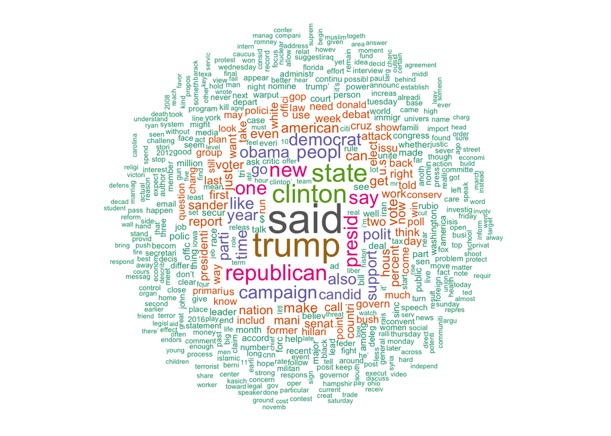

```r
library(quanteda.textplots)
library(RColorBrewer)
#we set a random seed for the cloud to be ordered always the same
set.seed(100)

textplot_wordcloud(realnews_dfm, min_count = 6, random_order = FALSE,
                   rotation = .25,
                   colors = RColorBrewer::brewer.pal(8,"Dark2"))
```

- Repeat the worldcloud without using stemming in the creation of the DFM. Is stemming being useful?

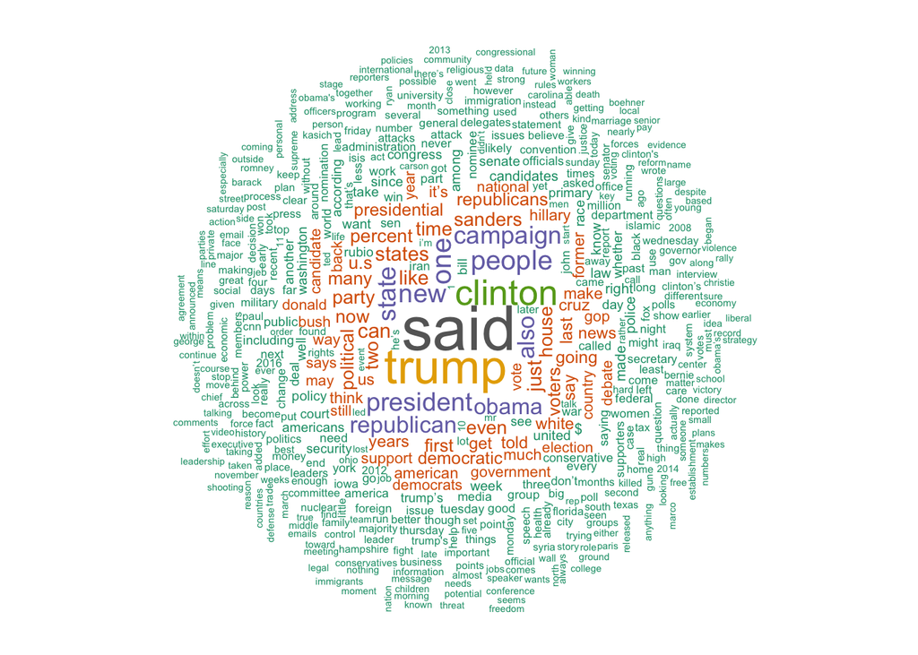

```r
realnews_dfm2 <- dfm(tokens_real_filtered)
set.seed(100)

textplot_wordcloud(realnews_dfm2, min_count = 6, random_order = FALSE,
                   rotation = .25,
                   colors = RColorBrewer::brewer.pal(8,"Dark2"))
```

A word cloud with stemming is not useful because you need to see the whole word. However, lemmatization is super helpful in word clouds, because you don’t want to see “university” and “universities”.